# Project 7 - Part I: Text Processing and Language Classification

### Razieh Pourhasan and Soufiane Fadel

- Objective
- Split the text corpus into train and test corpus
- Build Bi-Grams Language Models
- Visualizing the Bi-grams
  - English
  - German
  - Spanish
  - French
- Evaluation on Test Corpus
  - Confusion Matrix
  - Predicting the language of a random sentence or word

# Objective

Language classification is a supervised machine learning task of mapping a text to a unique language from a set of trained languages. It involves building language models from a lot of text data of respective languages and then identifying the test text data among the trained language models. In this project we try to build a language classifier for identifying four languages: English(en), German(de), Spanish(es) and French(fr).

We build our language models based on letter bi-grams from training text data for four languages. A bi-gram is a 2-character slice of a word. We also consider spaces as a character of the bi-grams in order to mark the distinction between beginning and end of word and the inner bi-grams. For example, a sentence “she sings” will have the following bi-grams:

*s, sh, he, e*, *s, si, in, ng, gs, s*

In a bi-grams model, we tokenize the text in characters (including spaces or underscores), generate bi-grams from these tokens and count the occurrence of each bi-grams. We then make a sorted list of bi-grams in descending order of their frequencies. The most frequent ones form a language model for training corpus of a particular language. We repeat this process to train a language model for each language of interest, here we have four.

For testing the model, we select large number (5000) of text sentences from a particular language (with known language label). We then tokenize each text sentence to bi-grams and their frequencies, and compare bi-grams to the bi-grams of each of 4 trained models and sum up the frequencies. We select the language with maximal sum as the language of a test sentence. We repeat this process 5000 times for each sentence in a test corpus of each language. Then we create a confusion matrix to check the accuracy of predicting the language of each test corpus.

To summarize, in the rest of this project, we walk through the following steps (including text processing whenever needed) and demonstrate the result and accuracy of our language model:

- Download the text corpus for 4 selected languages (English, German, Spanish and French) from the *Europal corpus* available online at http://www.statmt.org/europarl/. The text corpus are downloaded into 4 folders labeled as en, de, es and fr. Split the text corpus of each folder to train and test folders.
- Build bi-grams model for 4 selected languages (English, German, Spanish and French). The training corpus consists of all texts in the train folder.
- Test the language model on the test corpus consists of 5000 sentences for each language taken from the test folder.
- Test the language model on some random texts (sentence or word).

```python
import math
import os
import numpy as np
import pandas as pd
import matplotlib.pyplot as plt
import seaborn as sns
import plotly.offline as py
import plotly.graph_objs as go
import scipy.stats as ss
color = sns.color_palette()
sns.set(style="darkgrid")
from sklearn.preprocessing import StandardScaler, LabelEncoder, OneHotEncoder, MinMaxScaler
```

# Split the text corpus into train and test corpus

We split the texts in each language folder into 80% train and 20% test corpus.

```python
%%capture
import split_folders
import os

# Split with a ratio
input_folder = os.getcwd()
split_folders.ratio(input_folder, output="output", seed=1337, ratio=(.8, .2)) # default values
```

# Build Bi-Grams Language Models

This section include the following steps all done in the code below:

- Preprocessing of text in the training corpus which can improve the accuracy of the language identification task. We have considered the following preprocessing steps before creating bi-gram language model:
  - Texts have been extracted from each text file which is originally in `lxml` format.
  - Texts were converted to lower case.
  - The digits were removed from the texts.
  - Punctuation marks and special characters were removed.
  - All the texts in the train folder for each language were concatenated with space in between.
  - Series of contiguous white spaces were replaced by single space.
- Extracting the bi-grams and building language models:
  - Finding bi-grams and their frequencies will be achieved through `BigramCollocationFinder` function in nltk in Python.
  - Using other functions of `nltk` to find out list of bi-grams sorted with number of occurrences for each language. Keep only bi-grams with frequencies equal or higher than 5.
  - Saving a bi-grams language model for each of the 4 languages in `npy` format.

```python
import numpy as np
import pandas as pd
import os
import glob
import urllib
from bs4 import BeautifulSoup
from nltk.collocations import BigramCollocationFinder
import re
import codecs
import string

def train_language(label):
    text_all = []
    translate_table = dict((ord(char), ' ' ) for char in string.punctuation)
    filenames = os.listdir('train/' + label + '/')
    path = os.getcwd() + '/train/' + label + '/'
    for file in filenames:
        with codecs.open(path + file ,'r', encoding='utf-8') as infile:
            txt = infile.read()
        soup = BeautifulSoup(txt,'lxml')
        text = soup.get_text()
        text = text.replace('\n','')
        text = ' '.join(text.split()[0:])
        text = text.lower()   # to lower case
        text = re.sub(r'\d+', '', text) # remove digits
        text = text.translate(translate_table) # remove punctuations

        if len(text) != 0:
            text_all += text
            text_all.append(' ') # append texts with space

    all_str = ''.join(text_all)
    all_str = re.sub(' +',' ',all_str) # replace series of spaces with single space
    seq_all = [i for i in all_str]

    # extracting letter bi-grams and sorting them according to their frequencies
    finder = BigramCollocationFinder.from_words(seq_all)
    finder.apply_freq_filter(5) # keep bigrams with freuencies equal or greater than 5
    bigram_model = finder.ngram_fd.items()
    bigram_model = sorted(finder.ngram_fd.items(), key=lambda item: item[1],reverse=True) # sort based on frequency
    np.save(label+".npy",bigram_model) # save language model

if __name__ == "__main__":
    labels = ['en', 'de', 'es', 'fr']
    for label in labels:
        train_language(label)
```

# Visualizing the Bi-grams

In this section we demonstrate the `barplot` for the frequencies of inner bi-grams as well as beginning and end of word letters for English, German, Spanish and French language respectively.

## English

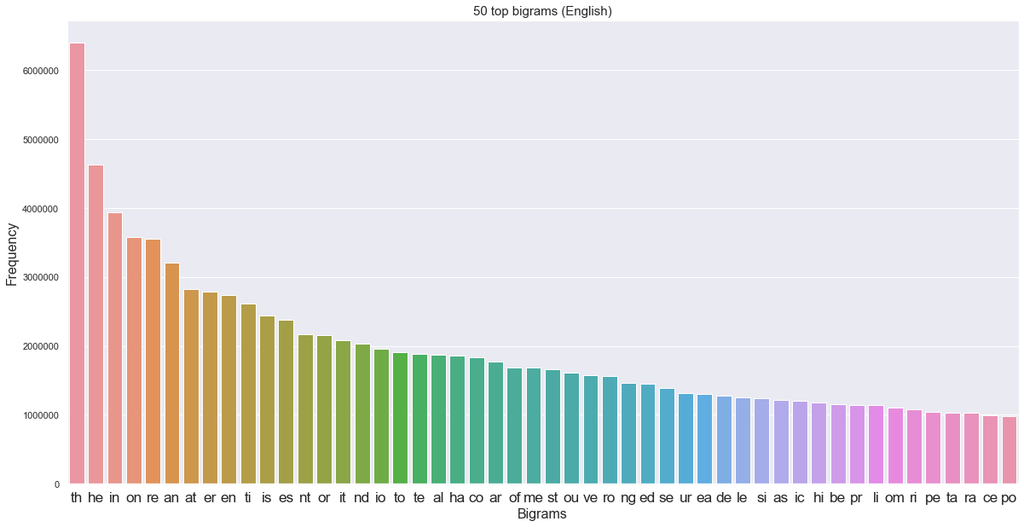

```python
import re

data = np.load('en.npy', allow_pickle=True)

df_bigram_letters = pd.DataFrame()
df_end_letters = pd.DataFrame()
df_start_letters = pd.DataFrame()

for j in range(0, len(data)-1):
    bigram = ''.join(data[j][0])
    if ' ' in bigram:
        if re.search('\S', bigram).start()==1:
            df_end_letters = df_end_letters.append([[bigram, data[j][1]]],ignore_index=True)
        else:
            df_start_letters = df_start_letters.append([[bigram, data[j][1]]],ignore_index=True)
    else:
        df_bigram_letters = df_bigram_letters.append([[bigram, data[j][1]]],ignore_index=True)


import matplotlib.pyplot as plt
import seaborn as sns

plt.figure(figsize=(20,10))
sns.barplot(df_bigram_letters[0].head(50), df_bigram_letters[1].head(50))
plt.xlabel('Bigrams', fontsize=16)
plt.ylabel('Frequency', fontsize=16)
plt.title('50 top bigrams (English)', fontsize=15)
plt.xticks(fontsize='x-large')
```

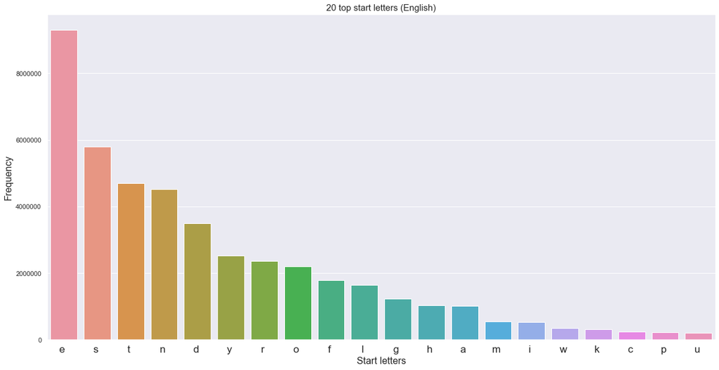

```python
plt.figure(figsize=(20,10))
sns.barplot(df_start_letters[0].head(20), df_start_letters[1].head(20))
plt.xlabel('Start letters', fontsize=16)
plt.ylabel('Frequency', fontsize=16)
plt.title('20 top start letters (English)', fontsize=15)
plt.xticks(fontsize='x-large')
```

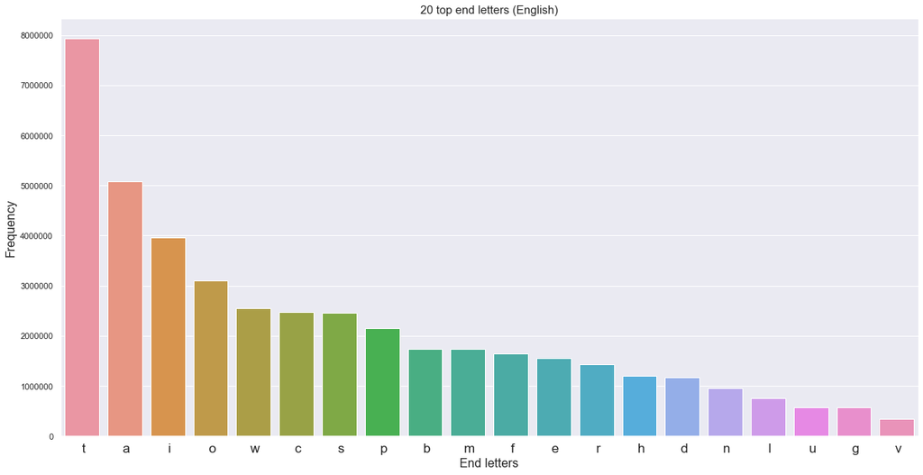

```python
plt.figure(figsize=(20,10))
sns.barplot(df_end_letters[0].head(20), df_end_letters[1].head(20))
plt.xlabel('End letters', fontsize=16)
plt.ylabel('Frequency', fontsize=16)
plt.title('20 top end letters (English)', fontsize=15)
plt.xticks(fontsize='x-large')
```

## German

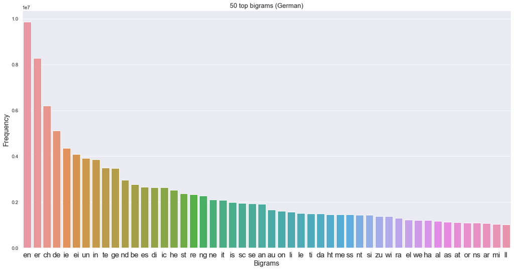

```python
import re

data = np.load('de.npy', allow_pickle=True)

df_bigram_letters = pd.DataFrame()
df_end_letters = pd.DataFrame()
df_start_letters = pd.DataFrame()

for j in range(0, len(data)-1):
    bigram = ''.join(data[j][0])
    if ' ' in bigram:
        if re.search('\S', bigram).start()==1:
            df_end_letters = df_end_letters.append([[bigram, data[j][1]]],ignore_index=True)
        else:
            df_start_letters = df_start_letters.append([[bigram, data[j][1]]],ignore_index=True)
    else:
        df_bigram_letters = df_bigram_letters.append([[bigram, data[j][1]]],ignore_index=True)


import matplotlib.pyplot as plt
import seaborn as sns

plt.figure(figsize=(20,10))
sns.barplot(df_bigram_letters[0].head(50), df_bigram_letters[1].head(50))
plt.xlabel('Bigrams', fontsize=16)
plt.ylabel('Frequency', fontsize=16)
plt.title('50 top bigrams (German)', fontsize=15)
plt.xticks(fontsize='x-large')
```

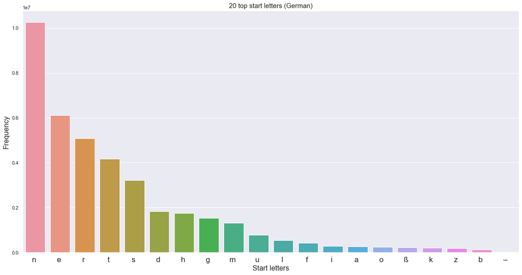

```python
plt.figure(figsize=(20,10))
sns.barplot(df_start_letters[0].head(20), df_start_letters[1].head(20))
plt.xlabel('Start letters', fontsize=16)
plt.ylabel('Frequency', fontsize=16)
plt.title('20 top start letters (German)', fontsize=15)
plt.xticks(fontsize='x-large')
```

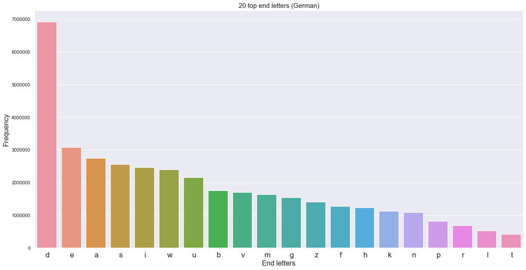

```python
plt.figure(figsize=(20,10))
sns.barplot(df_end_letters[0].head(20), df_end_letters[1].head(20))
plt.xlabel('End letters', fontsize=16)
plt.ylabel('Frequency', fontsize=16)
plt.title('20 top end letters (German)', fontsize=15)
plt.xticks(fontsize='x-large')
```

## Spanish

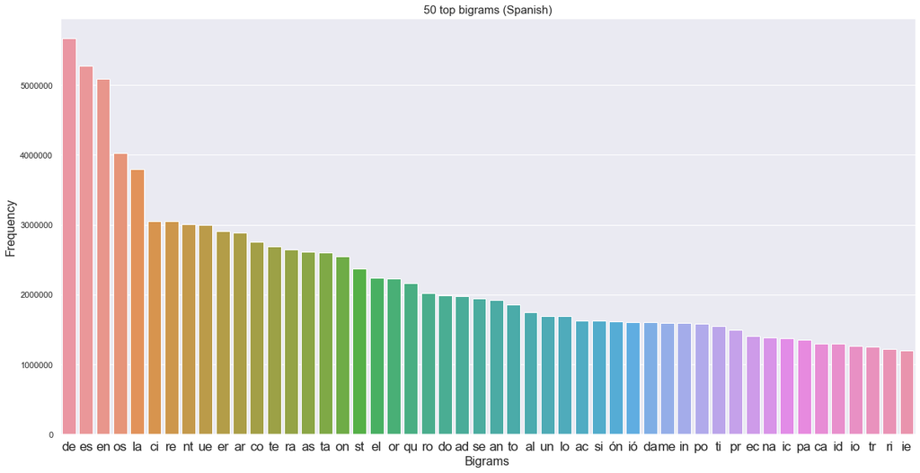

```python
import re

data = np.load('es.npy', allow_pickle=True)

df_bigram_letters = pd.DataFrame()
df_end_letters = pd.DataFrame()
df_start_letters = pd.DataFrame()

for j in range(0, len(data)-1):
    bigram = ''.join(data[j][0])
    if ' ' in bigram:
        if re.search('\S', bigram).start()==1:
            df_end_letters = df_end_letters.append([[bigram, data[j][1]]],ignore_index=True)
        else:
            df_start_letters = df_start_letters.append([[bigram, data[j][1]]],ignore_index=True)
    else:
        df_bigram_letters = df_bigram_letters.append([[bigram, data[j][1]]],ignore_index=True)


import matplotlib.pyplot as plt
import seaborn as sns

plt.figure(figsize=(20,10))
sns.barplot(df_bigram_letters[0].head(50), df_bigram_letters[1].head(50))
plt.xlabel('Bigrams', fontsize=16)
plt.ylabel('Frequency', fontsize=16)
plt.title('50 top bigrams (Spanish)', fontsize=15)
plt.xticks(fontsize='x-large')
```

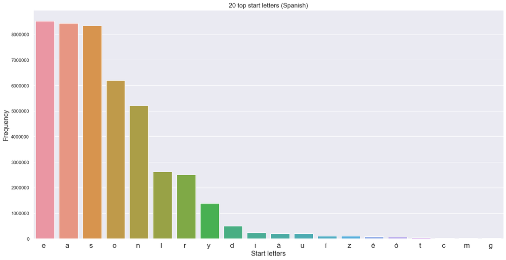

```python
plt.figure(figsize=(20,10))
sns.barplot(df_start_letters[0].head(20), df_start_letters[1].head(20))
plt.xlabel('Start letters', fontsize=16)
plt.ylabel('Frequency', fontsize=16)
plt.title('20 top start letters (Spanish)', fontsize=15)
plt.xticks(fontsize='x-large')
```

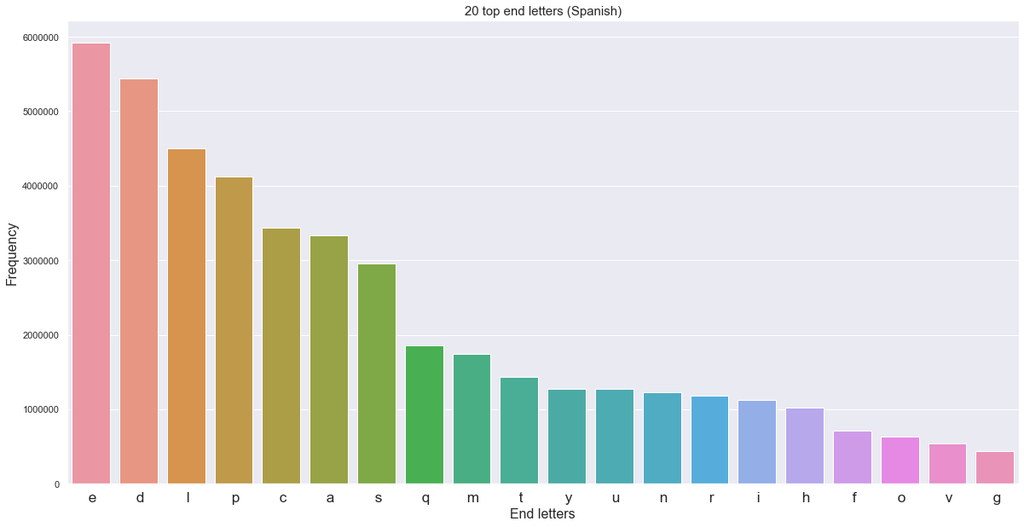

```python
plt.figure(figsize=(20,10))
sns.barplot(df_end_letters[0].head(20), df_end_letters[1].head(20))
plt.xlabel('End letters', fontsize=16)
plt.ylabel('Frequency', fontsize=16)
plt.title('20 top end letters (Spanish)', fontsize=15)
plt.xticks(fontsize='x-large')
```

## French

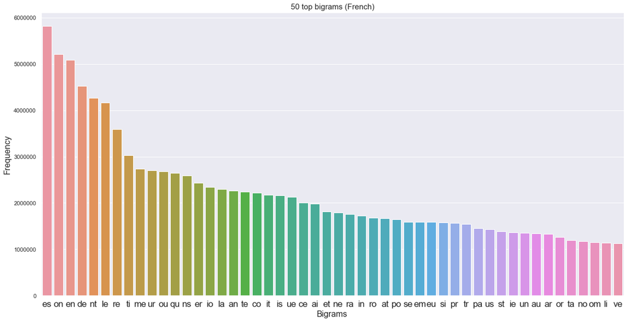

```python
import re

data = np.load('fr.npy', allow_pickle=True)

df_bigram_letters = pd.DataFrame()
df_end_letters = pd.DataFrame()
df_start_letters = pd.DataFrame()

for j in range(0, len(data)-1):
    bigram = ''.join(data[j][0])
    if ' ' in bigram:
        if re.search('\S', bigram).start()==1:
            df_end_letters = df_end_letters.append([[bigram, data[j][1]]],ignore_index=True)
        else:
            df_start_letters = df_start_letters.append([[bigram, data[j][1]]],ignore_index=True)
    else:
        df_bigram_letters = df_bigram_letters.append([[bigram, data[j][1]]],ignore_index=True)


import matplotlib.pyplot as plt
import seaborn as sns

plt.figure(figsize=(20,10))
sns.barplot(df_bigram_letters[0].head(50), df_bigram_letters[1].head(50))
plt.xlabel('Bigrams', fontsize=16)
plt.ylabel('Frequency', fontsize=16)
plt.title('50 top bigrams (French)', fontsize=15)
plt.xticks(fontsize='x-large')
```

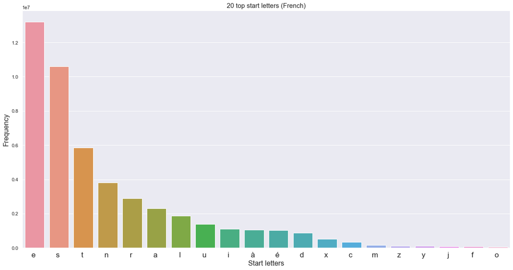

```python
plt.figure(figsize=(20,10))
sns.barplot(df_start_letters[0].head(20), df_start_letters[1].head(20))
plt.xlabel('Start letters', fontsize=16)
plt.ylabel('Frequency', fontsize=16)
plt.title('20 top start letters (French)', fontsize=15)
plt.xticks(fontsize='x-large')
```

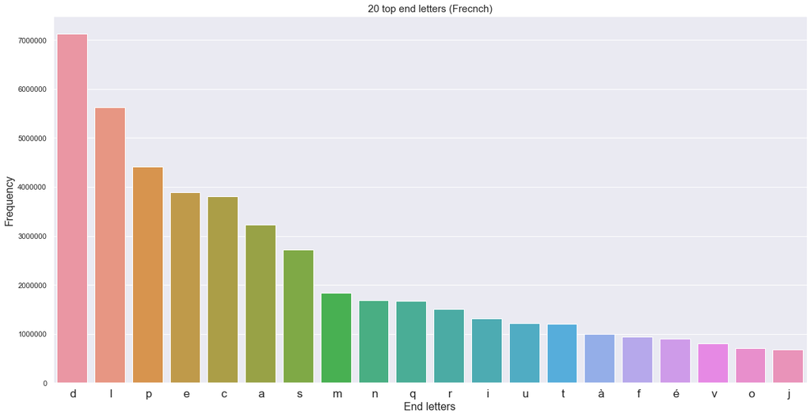

```python
plt.figure(figsize=(20,10))
sns.barplot(df_end_letters[0].head(20), df_end_letters[1].head(20))
plt.xlabel('End letters', fontsize=16)
plt.ylabel('Frequency', fontsize=16)
plt.title('20 top end letters (Frecnch)', fontsize=15)
plt.xticks(fontsize='x-large')
```

# Evaluation on Test Corpus

To carry with this procedure first, we preprocess the input sentence and extract the bi-grams from the input sentence. Then, we calculate the frequencies of each of these bi-grams from the language model and summed them up. Note that in order to remove any bias due to size of the training text corpus of each language, it is necessary to normalize the summed up frequency for each language by sum of frequencies of all the bi-grams in the respective language. Moreover, we multiply the frequencies by a factor of 5000 to avoid the case when normalized frequency become zero. The following equation is used for calculating the normalized frequencies: $$ f_n(j)=\frac{5000\sum_{j=1}^{k}f(i,j)}{\sum_{j=1}^{m}f(i,j)} $$

where $f_n(j)$ is the normalized frequency sum of language, $f(i,j)$ is the frequency of the $i^{th}$ bi-gram in $j^{th}$ language, $k$ is the number of bi-grams which occur in the test sentence and $m$ is the total number of bi-grams in the respective language model.

In the following code, after preprocessing of texts in test folder, we tokenize texts into sentences and randomly select 5000 sentences. We do that for all 4 languages:

```python
import numpy as np
import pandas as pd
import os
import glob
import urllib
from bs4 import BeautifulSoup
from nltk.collocations import BigramCollocationFinder
import re
import codecs
import string
from nltk.tokenize import sent_tokenize
import random


def sents_lan(label):

    text_all = []
    translate_table = dict((ord(char), ' ' ) for char in string.punctuation)

    filenames = os.listdir('test/' + label + '/')
    path = os.getcwd() + '/test/' + label + '/'

    for file in filenames:
        with codecs.open(path + file ,'r', encoding='utf-8') as infile:
            txt = infile.read()
        soup = BeautifulSoup(txt,'lxml')
        text = soup.get_text()
        text = text.replace('\n','')
        text = ' '.join(text.split()[0:])
        text = text.lower()   # to lower case
        text = re.sub(r'\d+', '', text)  # remove digits

        if len(text) != 0:
            text_all += text
            text_all.append(' ') # append texts with space

    all_str = ''.join(text_all)
    sents = sent_tokenize(all_str) # tokenize to sentences
    sents = random.choices(sents, k=5000) # choose 5000 sentences form test corpora
    sents = [sent.translate(translate_table) for sent in sents] # remove punctuations
    sents = [re.sub(' +',' ',sent) for sent in sents] # replace series of spaces with single space

    return sents

if __name__ == "__main__":

    labels = ['en', 'de', 'es', 'fr']
    sents_sample = []

    for label in labels:
        sents_sample.append([sents_lan(label),label])
        print(label)
```

```
en
de
es
fr
```

We check the number of sentences that we collected for each languages, one sample sentence and the language code for that sentence:

```python
for i, sent in enumerate(sents_sample):
    print(i,"  ",len(sent[0]),"  ",sent[0][0],"  ",sent[1])
```

```
0    5000    it is therefore all the more intriguing that seven minutes speaking time should have been allocated for such a relatively insignificant report when at other times there is not enough speaking time     en
1    5000    im rahmen der geteilten befugnisse wurden bereits zwei entschließungen verabschiedet und im rahmen des dritten pfeilers erfolgte eine gemeinsame aktion     de
2    5000    esa palabra equilibrio implica más que la palabra solidaridad que figura ahora en la propuesta     es
3    5000    pour éliminer les spams de l internet et punir ceux qui les font circuler     fr
```

Now that we have all the preprocessed sentences for all 4 languages, we use the frequency method explained in the beginning of this section to predict the language of each sentence. Then we compare the predicted outcome with the actual language label for each sentence. We do all that with the code below:

```python
from nltk.tokenize import sent_tokenize
import random

def test_language(total):

    lang_name = ['en', 'de', 'es', 'fr']
    model = [np.load(lang+".npy", allow_pickle=True) for lang in lang_name]
    df_confusion = pd.DataFrame()

    for i, sent in enumerate(sents_sample):
        enp = 0
        dep = 0
        esp = 0
        frp = 0
        ccd = 0
        for j in range(0,len(sent[0])-1):
            finder = BigramCollocationFinder.from_words(sent[0][j])
            freq_sum = np.zeros(4)
            for k,v in finder.ngram_fd.items():
                isthere = 0
                for i,lang in enumerate(lang_name):
                    for key,f in model[i]:
                        if k == key:
                            freq_sum[i] = freq_sum[i]+(f*5000)/total[i]
                            isthere = 1
                            break
                if isthere == 0:
                    freq_sum[i] = freq_sum[i] + 1

            max_val = freq_sum.max()
            index= freq_sum.argmax()

            if max_val != 0:
                if lang_name[index] == lang_name[0]:
                    enp = enp + 1
                elif lang_name[index] == lang_name[1]:
                    dep = dep + 1
                elif lang_name[index] == lang_name[2]:
                    esp = esp + 1
                elif lang_name[index] == lang_name[3]:
                    frp = frp + 1
            else:
                ccd = ccd + 1

        df_confusion = df_confusion.append([[enp, dep, esp, frp, ccd]],ignore_index=True)

    return df_confusion


labels = ['en', 'de', 'es', 'fr']
no_of_bigms = []
for label in labels:
    model = np.load(label+".npy", allow_pickle=True)
    total = 0
    for key,v in model:
        total = total + v
    no_of_bigms.append(total)

df = test_language(no_of_bigms)
```

```python
df.columns = ['English', 'German', 'Spanish', 'French', 'Other']
df.insert(loc=0 , column='Languages', value=['English', 'German', 'Spanish', 'French'])
```

## Confusion Matrix

```python
# create confusion matrix
from tabulate import tabulate

df1 = df.set_index(['Languages'])
print(tabulate(df1, tablefmt="fancy_grid", headers="keys"))
```

```
╒═════════════╤═══════════╤══════════╤═══════════╤══════════╤═════════╕
│ Languages   │   English │   German │   Spanish │   French │   Other │
╞═════════════╪═══════════╪══════════╪═══════════╪══════════╪═════════╡
│ English     │      4857 │       19 │        29 │       60 │      34 │
├─────────────┼───────────┼──────────┼───────────┼──────────┼─────────┤
│ German      │         8 │     4915 │         6 │       33 │      37 │
├─────────────┼───────────┼──────────┼───────────┼──────────┼─────────┤
│ Spanish     │         4 │        6 │      4935 │       13 │      41 │
├─────────────┼───────────┼──────────┼───────────┼──────────┼─────────┤
│ French      │         2 │       12 │        34 │     4923 │      28 │
╘═════════════╧═══════════╧══════════╧═══════════╧══════════╧═════════╛
```

## Predicting the language of a random sentence or word

The accuracy of our language classifier is pretty good. Now we can use it to predict the language of a random sentence or word of our choice. The function `test_sent(sentence/word)` take a sentence or a word and predict the language. Below, we try some sentences and words to identify the language:

```python
# create a function to predict the language of a sentence or a word
def test_sent(sentence):

    df_pred = pd.DataFrame()
    enp = 0
    dep = 0
    esp = 0
    frp = 0
    ccd = 0
    lang_name = ['en', 'de', 'es', 'fr']
    model = [np.load(lang+".npy", allow_pickle=True) for lang in lang_name]

    translate_table = dict((ord(char), ' ' ) for char in string.punctuation)

    sentence = sentence.lower()
    sentence = re.sub(r'\d+', '', sentence)
    sentence = sentence.translate(translate_table)
    sentence = re.sub(' +',' ',sentence)

    finder = BigramCollocationFinder.from_words(sentence)
    freq_sum = np.zeros(4)
    for k,v in finder.ngram_fd.items():
        isthere = 0
        for i,lang in enumerate(lang_name):
            for key,f in model[i]:
                if k == key:
                    freq_sum[i] = freq_sum[i]+(f*5000)/no_of_bigms[i]
                    isthere = 1
                    break
            if isthere == 0:
                freq_sum[i] = freq_sum[i] + 1

    max_val = freq_sum.max()
    index= freq_sum.argmax()

    if max_val != 0:
        if lang_name[index] == lang_name[0]:
            enp = enp + 1
        elif lang_name[index] == lang_name[1]:
            dep = dep + 1
        elif lang_name[index] == lang_name[2]:
            esp = esp + 1
        elif lang_name[index] == lang_name[3]:
            frp = frp + 1
    else:
        ccd = ccd + 1
    df_pred = df_pred.append([[enp, dep, esp, frp, ccd]],ignore_index=True)
    df_pred.columns = ['English', 'German', 'Spanish', 'French', 'Other']
    df_pred.insert(loc=0 , column='Prediction', value=[sentence])
    df_pred = df_pred.set_index(['Prediction'])
    print(tabulate(df_pred, tablefmt="fancy_grid", headers="keys"))
```

```python
word = "mais c’est très important"
test_sent(word)
```

```
╒═══════════════════════════╤═══════════╤══════════╤═══════════╤══════════╤═════════╕
│ Prediction                │   English │   German │   Spanish │   French │   Other │
╞═══════════════════════════╪═══════════╪══════════╪═══════════╪══════════╪═════════╡
│ mais c’est très important │         0 │        0 │         0 │        1 │       0 │
╘═══════════════════════════╧═══════════╧══════════╧═══════════╧══════════╧═════════╛
```

```python
word = "Poursuivre"
test_sent(word)
```

```
╒══════════════╤═══════════╤══════════╤═══════════╤══════════╤═════════╕
│ Prediction   │   English │   German │   Spanish │   French │   Other │
╞══════════════╪═══════════╪══════════╪═══════════╪══════════╪═════════╡
│ poursuivre   │         0 │        0 │         0 │        1 │       0 │
╘══════════════╧═══════════╧══════════╧═══════════╧══════════╧═════════╛
```

```python
word = "Jacques"
test_sent(word)
```

```
╒══════════════╤═══════════╤══════════╤═══════════╤══════════╤═════════╕
│ Prediction   │   English │   German │   Spanish │   French │   Other │
╞══════════════╪═══════════╪══════════╪═══════════╪══════════╪═════════╡
│ jacques      │         0 │        0 │         1 │        0 │       0 │
╘══════════════╧═══════════╧══════════╧═══════════╧══════════╧═════════╛
```

```python
word = "Aimée"
test_sent(word)
```

```
╒══════════════╤═══════════╤══════════╤═══════════╤══════════╤═════════╕
│ Prediction   │   English │   German │   Spanish │   French │   Other │
╞══════════════╪═══════════╪══════════╪═══════════╪══════════╪═════════╡
│ aimée        │         0 │        0 │         0 │        1 │       0 │
╘══════════════╧═══════════╧══════════╧═══════════╧══════════╧═════════╛
```

```python
word = "Comenzó su andadura en mayo de 2001"
test_sent(word)
```

```
╒════════════════════════════════╤═══════════╤══════════╤═══════════╤══════════╤═════════╕
│ Prediction                     │   English │   German │   Spanish │   French │   Other │
╞════════════════════════════════╪═══════════╪══════════╪═══════════╪══════════╪═════════╡
│ comenzó su andadura en mayo de │         0 │        0 │         1 │        0 │       0 │
╘════════════════════════════════╧═══════════╧══════════╧═══════════╧══════════╧═════════╛
```

```python
word = "Merci Beaucoup"
test_sent(word)
```

```
╒════════════════╤═══════════╤══════════╤═══════════╤══════════╤═════════╕
│ Prediction     │   English │   German │   Spanish │   French │   Other │
╞════════════════╪═══════════╪══════════╪═══════════╪══════════╪═════════╡
│ merci beaucoup │         0 │        1 │         0 │        0 │       0 │
╘════════════════╧═══════════╧══════════╧═══════════╧══════════╧═════════╛
```

```python
word = "Merci bien"
test_sent(word)
```

```
╒══════════════╤═══════════╤══════════╤═══════════╤══════════╤═════════╕
│ Prediction   │   English │   German │   Spanish │   French │   Other │
╞══════════════╪═══════════╪══════════╪═══════════╪══════════╪═════════╡
│ merci bien   │         0 │        1 │         0 │        0 │       0 │
╘══════════════╧═══════════╧══════════╧═══════════╧══════════╧═════════╛
```

It fails in predicting the most common French expressions, *Merci Beaucoup* and *Merci Bien*!

```python
word = "Bonjour"
test_sent(word)
```

```
╒══════════════╤═══════════╤══════════╤═══════════╤══════════╤═════════╕
│ Prediction   │   English │   German │   Spanish │   French │   Other │
╞══════════════╪═══════════╪══════════╪═══════════╪══════════╪═════════╡
│ bonjour      │         0 │        0 │         0 │        1 │       0 │
╘══════════════╧═══════════╧══════════╧═══════════╧══════════╧═════════╛
```

```python
word = "Objekt oft eine Gottheit oder deren Wirken"
test_sent(word)
```

```
╒════════════════════════════════════════════╤═══════════╤══════════╤═══════════╤══════════╤═════════╕
│ Prediction                                 │   English │   German │   Spanish │   French │   Other │
╞════════════════════════════════════════════╪═══════════╪══════════╪═══════════╪══════════╪═════════╡
│ objekt oft eine gottheit oder deren wirken │         0 │        1 │         0 │        0 │       0 │
╘════════════════════════════════════════════╧═══════════╧══════════╧═══════════╧══════════╧═════════╛
```

```python
word = "Henry"
test_sent(word)
```

```
╒══════════════╤═══════════╤══════════╤═══════════╤══════════╤═════════╕
│ Prediction   │   English │   German │   Spanish │   French │   Other │
╞══════════════╪═══════════╪══════════╪═══════════╪══════════╪═════════╡
│ henry        │         0 │        1 │         0 │        0 │       0 │
╘══════════════╧═══════════╧══════════╧═══════════╧══════════╧═════════╛
```

Now, you can give it a try yourself: input a word or a sentence

```python
word = #input a word or a sentence
test_sent(word)
```